# Consultas SPARQL sobre el Grafo de Cronobiología

Papel de los Genes del Reloj Circadiano en los Trastornos del Sueño

Laura Llamas López

Enero 2026

# 1 Introducción

Este documento contiene **5 consultas SPARQL** (incluyendo 4a y 4b) diseñadas para explotar semánticamente un grafo RDF sobre **cronobiología**. Las consultas extraen conocimiento biomédico integrado sobre genes del reloj circadiano, variantes patogénicas, interacciones proteicas, análisis de redes, correlaciones genotipo-fenotipo y opciones terapéuticas.

# 2 Instalación y Configuración

## 2.1 Librerías necesarias

```r
# Ejecutar solo la primera vez
install.packages("SPARQL")
install.packages("ggplot2")
install.packages("DT")
install.packages("knitr")
```

```r
library(SPARQL)
library(ggplot2)
library(DT)
library(knitr)
```

## 2.2 Configuración del Endpoint SPARQL

```r
# Endpoint de Blazegraph
endpoint <- "http://dayhoff.inf.um.es:3039/blazegraph/namespace/cronobiologia/sparql"

# Timeout para consultas remotas (segundos)
options(timeout = 30)

# Función para ejecutar consultas SPARQL
ejecutar_consulta <- function(query) {
  resultado <- SPARQL(endpoint, query)
  return(as.data.frame(resultado$results))
}
```

# 3 CONSULTA 0: Verificación del Grafo RDF

## 3.1 Objetivo

Consulta de **control de calidad** que verifica la carga correcta del grafo RDF en Blazegraph. **Utilidad biomédica:**  
✓ Control de calidad del proceso ETL (Extract-Transform-Load)  
✓ Verificación de integridad de datos antes de análisis clínicos

## 3.2 Ejecución

```r
# Paso 1: Contar total de tripletas
consulta0_count <- '
SELECT (COUNT(*) AS ?total)
WHERE {
  ?sujeto ?predicado ?objeto .
}
'

total_tripletas <- ejecutar_consulta(consulta0_count)
cat("Total de tripletas en el grafo:", total_tripletas$total, "\n\n")
```

```
Total de tripletas en el grafo: 436
```

```r
# Paso 2: Recuperar tripletas
consulta0 <- '
SELECT ?sujeto ?predicado ?objeto
WHERE {
    ?sujeto ?predicado ?objeto .
}
ORDER BY ?sujeto ?predicado
'

resultados0 <- ejecutar_consulta(consulta0)
```

## 3.3 Resultados

```r
datatable(resultados0, options = list(pageLength=10))
```

|  | sujeto | predicado | objeto |
| --- | --- | --- | --- |
| 1 | &lt;http://cronobiologia.um.es/ontologia/afectaGen&gt; | &lt;http://www.w3.org/1999/02/22-rdf-syntax-ns#type&gt; | &lt;http://www.w3.org/2002/07/owl#ObjectProperty&gt; |
| 2 | &lt;http://cronobiologia.um.es/ontologia/afectaGen&gt; | &lt;http://www.w3.org/2000/01/rdf-schema#label&gt; | "afecta al gen"@es |
| 3 | &lt;http://cronobiologia.um.es/ontologia/afectaGen&gt; | &lt;http://www.w3.org/2000/01/rdf-schema#seeAlso&gt; | &lt;https://w3id.org/biolink/vocab/affects&gt; |
| 4 | &lt;http://cronobiologia.um.es/ontologia/causaTrastorno&gt; | &lt;http://www.w3.org/1999/02/22-rdf-syntax-ns#type&gt; | &lt;http://www.w3.org/2002/07/owl#ObjectProperty&gt; |
| 5 | &lt;http://cronobiologia.um.es/ontologia/causaTrastorno&gt; | &lt;http://www.w3.org/2000/01/rdf-schema#label&gt; | "causa trastorno"@es |
| 6 | &lt;http://cronobiologia.um.es/ontologia/causaTrastorno&gt; | &lt;http://www.w3.org/2000/01/rdf-schema#seeAlso&gt; | &lt;http://purl.obolibrary.org/obo/RO_0003303&gt; |
| 7 | &lt;http://cronobiologia.um.es/ontologia/causaTrastorno&gt; | &lt;http://www.w3.org/2000/01/rdf-schema#seeAlso&gt; | &lt;https://w3id.org/biolink/vocab/causes&gt; |
| 8 | &lt;http://cronobiologia.um.es/ontologia/codifica&gt; | &lt;http://www.w3.org/1999/02/22-rdf-syntax-ns#type&gt; | &lt;http://www.w3.org/2002/07/owl#ObjectProperty&gt; |
| 9 | &lt;http://cronobiologia.um.es/ontologia/codifica&gt; | &lt;http://www.w3.org/2000/01/rdf-schema#label&gt; | "codifica"@es |
| 10 | &lt;http://cronobiologia.um.es/ontologia/codifica&gt; | &lt;http://www.w3.org/2000/01/rdf-schema#seeAlso&gt; | &lt;http://purl.obolibrary.org/obo/RO_0002205&gt; |

[output cut: 426 more lines]

# 4 Consulta 1: Trastornos y Fenotipos Clínicos Asociados

## 4.1 Pregunta de Investigación

> *¿Qué fenotipos clínicos caracterizan cada trastorno del sueño?*

## 4.2 Interés Biomédico

La correlación genotipo-fenotipo es fundamental para el diagnóstico diferencial entre trastornos circadianos, medicina de precisión e investigación traslacional. El mapeo con Human Phenotype Ontology (HPO) permite la interoperabilidad con bases de datos clínicas.

## 4.3 Consulta SPARQL

```r
consulta1 <- '
PREFIX crono: <http://cronobiologia.um.es/recurso/>
PREFIX crono_o: <http://cronobiologia.um.es/ontologia/>
PREFIX rdf: <http://www.w3.org/1999/02/22-rdf-syntax-ns#>
PREFIX rdfs: <http://www.w3.org/2000/01/rdf-schema#>
PREFIX biolink: <https://w3id.org/biolink/vocab/>

SELECT ?trastorno ?nombreTrastorno ?fenotipo ?nombreFenotipo ?descripcionFenotipo ?hpo
WHERE {
  ?trastorno rdf:type biolink:Disease ;
             rdfs:label ?nombreTrastorno ;
             crono_o:tieneFenotipo ?fenotipo .

  ?fenotipo rdfs:label ?nombreFenotipo ;
            rdfs:comment ?descripcionFenotipo .

  OPTIONAL {
    ?fenotipo rdfs:seeAlso ?hpo .
    FILTER(CONTAINS(STR(?hpo), "HP_"))
  }
}
ORDER BY ?nombreTrastorno ?nombreFenotipo
'

resultados1 <- ejecutar_consulta(consulta1)
```

## 4.4 Resultados

```r
datatable(resultados1, options = list(pageLength = 10))
```

|  | trastorno | nombreTrastorno | fenotipo | nombreFenotipo | descripcionFenotipo | hpo |
| --- | --- | --- | --- | --- | --- | --- |
| 1 | &lt;http://cronobiologia.um.es/recurso/Trastorno_Insomnio&gt; | "Insomnio Crónico"@es | &lt;http://cronobiologia.um.es/recurso/Fenotipo_CalidadPobreSueno&gt; | "Calidad pobre del sueño"@es | "Sueño no reparador."@es | &lt;http://purl.obolibrary.org/obo/HP_4000064&gt; |
| 2 | &lt;http://cronobiologia.um.es/recurso/Trastorno_Insomnio&gt; | "Insomnio Crónico"@es | &lt;http://cronobiologia.um.es/recurso/Fenotipo_DespertarTemprano&gt; | "Despertar temprano"@es | "Despertar antes de lo deseado y no poder volver a dormir."@es | &lt;http://purl.obolibrary.org/obo/HP_0031356&gt; |
| 3 | &lt;http://cronobiologia.um.es/recurso/Trastorno_Insomnio&gt; | "Insomnio Crónico"@es | &lt;http://cronobiologia.um.es/recurso/Fenotipo_DificultadMantener&gt; | "Dificultad mantener sueño"@es | "Despertares frecuentes nocturnos."@es | &lt;http://purl.obolibrary.org/obo/HP_0031355&gt; |
| 4 | &lt;http://cronobiologia.um.es/recurso/Trastorno_Insomnio&gt; | "Insomnio Crónico"@es | &lt;http://cronobiologia.um.es/recurso/Fenotipo_DificultadConciliar&gt; | "Dificultad para conciliar el sueño"@es | "Incapacidad para dormirse a hora convencional."@es | &lt;http://purl.obolibrary.org/obo/HP_0031354&gt; |
| 5 | &lt;http://cronobiologia.um.es/recurso/Trastorno_Insomnio&gt; | "Insomnio Crónico"@es | &lt;http://cronobiologia.um.es/recurso/Fenotipo_PatronSuenoAlterado&gt; | "Patrón de sueño alterado"@es | "Desincronización del ciclo sueño-vigilia."@es | &lt;http://purl.obolibrary.org/obo/HP_0006979&gt; |
| 6 | &lt;http://cronobiologia.um.es/recurso/Trastorno_Insomnio&gt; | "Insomnio Crónico"@es | &lt;http://cronobiologia.um.es/recurso/Fenotipo_SomnolenciaDiurna&gt; | "Somnolencia diurna excesiva"@es | "Excesiva propensión al sueño diurno."@es | &lt;http://purl.obolibrary.org/obo/HP_0001262&gt; |
| 7 | &lt;http://cronobiologia.um.es/recurso/Trastorno_Insomnio&gt; | "Insomnio Crónico"@es | &lt;http://cronobiologia.um.es/recurso/Fenotipo_SuenoFragmentado&gt; | "Sueño fragmentado"@es | "Múltiples episodios breves de sueño sin consolidación."@es | &lt;http://purl.obolibrary.org/obo/HP_0025199&gt; |
| 8 | &lt;http://cronobiologia.um.es/recurso/Trastorno_ASPD&gt; | "Trastorno de Fase de Sueño Adelantada"@es | &lt;http://cronobiologia.um.es/recurso/Fenotipo_DesincronizacionCircadiana&gt; | "Desincronización circadiana"@es | "Ritmo circadiano no alineado con ciclo de 24h."@es | &lt;http://purl.obolibrary.org/obo/HP_0025365&gt; |
| 9 | &lt;http://cronobiologia.um.es/recurso/Trastorno_ASPD&gt; | "Trastorno de Fase de Sueño Adelantada"@es | &lt;http://cronobiologia.um.es/recurso/Fenotipo_DespertarTemprano&gt; | "Despertar temprano"@es | "Despertar antes de lo deseado y no poder volver a dormir."@es | &lt;http://purl.obolibrary.org/obo/HP_0031356&gt; |
| 10 | &lt;http://cronobiologia.um.es/recurso/Trastorno_ASPD&gt; | "Trastorno de Fase de Sueño Adelantada"@es | &lt;http://cronobiologia.um.es/recurso/Fenotipo_SomnolenciaTemprana&gt; | "Inicio de sueño temprano"@es | "Inicio del sueño en horas tempranas (18-21h). Característica de ASPD."@es | &lt;http://purl.obolibrary.org/obo/HP_0031873&gt; |

[output cut: 19 more lines]

# 5 Consulta 2: Tratamientos Farmacológicos y Trastornos Diana

## 5.1 Pregunta de Investigación

> *¿Qué fármacos están indicados para cada trastorno circadiano y cuál es su mecanismo básico?*

## 5.2 Interés Biomédico

Permite:

- **Visualizar opciones terapéuticas** por trastorno
- **Comparar tratamientos** entre patologías
- **Identificar fármacos compartidos** (melatonina como eje terapéutico)

## 5.3 Consulta SPARQL

```r
consulta2 <- '
PREFIX crono: <http://cronobiologia.um.es/recurso/>
PREFIX crono_o: <http://cronobiologia.um.es/ontologia/>
PREFIX rdf: <http://www.w3.org/1999/02/22-rdf-syntax-ns#>
PREFIX rdfs: <http://www.w3.org/2000/01/rdf-schema#>
PREFIX biolink: <https://w3id.org/biolink/vocab/>

SELECT ?nombreTrastorno ?nombreFarmaco ?mecanismo ?drugbank
WHERE {
  ?trastorno rdf:type biolink:Disease ;
             rdfs:label ?nombreTrastorno ;
             crono_o:tratadoCon ?farmaco .

  ?farmaco rdfs:label ?nombreFarmaco ;
           rdfs:comment ?mecanismo .

  OPTIONAL {
    ?farmaco rdfs:seeAlso ?drugbank .
    FILTER(CONTAINS(STR(?drugbank), "drugbank"))
  }
}
ORDER BY ?nombreTrastorno ?nombreFarmaco
'

resultados2 <- ejecutar_consulta(consulta2)
```

## 5.4 Resultados

```r
datatable(resultados2, options = list(pageLength = 10))
```

|  | nombreTrastorno | nombreFarmaco | mecanismo | drugbank |
| --- | --- | --- | --- | --- |
| 1 | "Insomnio Crónico"@es | "Melatonina"@es | "Hormona endógena para sincronización circadiana. Agonista MT1/MT2. Administración: por la noche en DSPD e insomnio; por la mañana en ASPD."@es | &lt;https://go.drugbank.com/drugs/DB01065&gt; |
| 2 | "Insomnio Crónico"@es | "Ramelteon"@es | "Agonista selectivo de receptores de melatonina."@es | &lt;https://go.drugbank.com/drugs/DB00980&gt; |
| 3 | "Trastorno de Fase de Sueño Adelantada"@es | "Melatonina"@es | "Hormona endógena para sincronización circadiana. Agonista MT1/MT2. Administración: por la noche en DSPD e insomnio; por la mañana en ASPD."@es | &lt;https://go.drugbank.com/drugs/DB01065&gt; |
| 4 | "Trastorno de Fase de Sueño Retrasada"@es | "Melatonina"@es | "Hormona endógena para sincronización circadiana. Agonista MT1/MT2. Administración: por la noche en DSPD e insomnio; por la mañana en ASPD."@es | &lt;https://go.drugbank.com/drugs/DB01065&gt; |
| 5 | "Trastorno de Fase de Sueño Retrasada"@es | "Ramelteon"@es | "Agonista selectivo de receptores de melatonina."@es | &lt;https://go.drugbank.com/drugs/DB00980&gt; |
| 6 | "Trastorno de Ritmo Sueño-Vigilia Irregular"@es | "Melatonina"@es | "Hormona endógena para sincronización circadiana. Agonista MT1/MT2. Administración: por la noche en DSPD e insomnio; por la mañana en ASPD."@es | &lt;https://go.drugbank.com/drugs/DB01065&gt; |
| 7 | "Trastorno de Sueño-Vigilia No-24 Horas"@es | "Tasimelteon"@es | "Agonista dual MT1/MT2, aprobado para Non-24."@es | &lt;https://go.drugbank.com/drugs/DB09071&gt; |

# 6 Consulta 3: Mutaciones Missense Patogénicas que Causan Adelanto de Fase

## 6.1 Pregunta de Investigación

> *¿Qué mutaciones de tipo missense con patogenicidad confirmada causan el Trastorno de Fase de Sueño Adelantada (ASPD)?*

## 6.2 Interés Biomédico

El **Trastorno de Fase de Sueño Adelantada (ASPD)** es un trastorno circadiano caracterizado por:

- Somnolencia extrema entre las 18:00-21:00
- Despertar espontáneo entre las 2:00-5:00 AM
- Imposibilidad de mantenerse despierto en horarios convencionales

Las **mutaciones missense** en genes como *PER2* y *CSNK1D* alteran la fosforilación de las proteínas PER, acortando el período circadiano.

## 6.3 Consulta SPARQL

```r
consulta3 <- '
PREFIX crono: <http://cronobiologia.um.es/recurso/>
PREFIX crono_o: <http://cronobiologia.um.es/ontologia/>
PREFIX rdf: <http://www.w3.org/1999/02/22-rdf-syntax-ns#>
PREFIX rdfs: <http://www.w3.org/2000/01/rdf-schema#>
PREFIX biolink: <https://w3id.org/biolink/vocab/>
PREFIX xsd: <http://www.w3.org/2001/XMLSchema#>

SELECT ?variante ?nombreVariante ?nombreGen ?patogenicidad ?herencia ?clinvar ?descripcion
WHERE {
    ?variante rdf:type biolink:SequenceVariant ;
              rdfs:label ?nombreVariante ;
              rdfs:comment ?descripcion ;
              crono_o:afectaGen ?gen ;
              crono_o:causaTrastorno crono:Trastorno_ASPD ;
              crono_o:tipoMutacion crono:TipoMutacion_Missense .

    ?variante crono_o:tienePatogenicidad ?patogenicidad .
    FILTER(?patogenicidad = "Patogénica"^^xsd:string)

    ?gen rdfs:label ?nombreGen .

    ?variante crono_o:tienePatronHerencia ?herenciaUri .
    ?herenciaUri rdfs:label ?herencia .

    OPTIONAL {
        ?variante rdfs:seeAlso ?clinvar .
        FILTER(CONTAINS(STR(?clinvar), "clinvar"))
    }
}
ORDER BY ?nombreGen ?nombreVariante
'

resultados3 <- ejecutar_consulta(consulta3)
```

## 6.4 Resultados

```r
datatable(resultados3, options = list(pageLength = 10))
```

|  | variante | nombreVariante | nombreGen | patogenicidad | herencia | clinvar | descripcion |
| --- | --- | --- | --- | --- | --- | --- | --- |
| 1 | &lt;http://cronobiologia.um.es/recurso/Variante_CSNK1D_Thr44Ala&gt; | "CSNK1D p.Thr44Ala"@es | "CSNK1D"@es | Patogénica | "Herencia autosómica dominante"@es | &lt;https://www.ncbi.nlm.nih.gov/clinvar/variation/8741&gt; | "Mutación missense que causa ASPD. Reduce actividad quinasa."@es |
| 2 | &lt;http://cronobiologia.um.es/recurso/Variante_PER2_Ser662Gly&gt; | "PER2 p.Ser662Gly"@es | "PER2"@es | Patogénica | "Herencia autosómica dominante"@es | &lt;https://www.ncbi.nlm.nih.gov/clinvar/variation/6345&gt; | "Mutación missense en PER2 que causa ASPD. Altera fosforilación por CK1ε."@es |

# 7 Consulta 4a: Interacciones y Regulación del Reloj Circadiano

## 7.1 Pregunta de Investigación

> *¿Qué relaciones de interacción física y regulación (positiva/negativa) existen en el oscilador circadiano?*

## 7.2 Interés Biomédico

Esta consulta reconstruye la **red de interacción + regulación** del TTFL, útil para:

- **Modelado del oscilador molecular**
- **Identificación de dianas** (hubs regulatorios)
- **Interpretación de variantes** en genes reguladores

## 7.3 Consulta SPARQL

```r
consulta4a <- '
PREFIX crono: <http://cronobiologia.um.es/recurso/>
PREFIX crono_o: <http://cronobiologia.um.es/ontologia/>
PREFIX rdf: <http://www.w3.org/1999/02/22-rdf-syntax-ns#>
PREFIX rdfs: <http://www.w3.org/2000/01/rdf-schema#>

SELECT ?origenLabel ?tipoRelacion ?destinoLabel ?destinoTipo
WHERE {
  {
    # Interacciones físicas proteína-proteína
    ?origen crono_o:interactuaCon ?destino .
    BIND("Interacción física (PPI)" AS ?tipoRelacion)
  }
  UNION
  {
    # Regulación transcripcional positiva
    ?origen crono_o:regulaPositivamente ?destino .
    BIND("Regulación positiva" AS ?tipoRelacion)
  }
  UNION
  {
    # Regulación transcripcional negativa
    ?origen crono_o:regulaNegativamente ?destino .
    BIND("Regulación negativa" AS ?tipoRelacion)
  }

  ?origen rdfs:label ?origenLabel .
  ?destino rdfs:label ?destinoLabel .
  OPTIONAL { ?destino rdf:type ?destinoTipo . }
}
ORDER BY ?tipoRelacion ?origenLabel ?destinoLabel
'

resultados4a <- ejecutar_consulta(consulta4a)
```

## 7.4 Resultados

```r
datatable(resultados4a, options = list(pageLength = 10))
```

|  | origenLabel | tipoRelacion | destinoLabel | destinoTipo |
| --- | --- | --- | --- | --- |
| 1 | "Caseína quinasa I delta"@es | Interacción física (PPI) | "Proteína PER1"@es | &lt;https://w3id.org/biolink/vocab/Protein&gt; |
| 2 | "Caseína quinasa I delta"@es | Interacción física (PPI) | "Proteína PER2"@es | &lt;https://w3id.org/biolink/vocab/Protein&gt; |
| 3 | "Caseína quinasa I delta"@es | Interacción física (PPI) | "Proteína PER3"@es | &lt;https://w3id.org/biolink/vocab/Protein&gt; |
| 4 | "Caseína quinasa I epsilon"@es | Interacción física (PPI) | "Proteína PER1"@es | &lt;https://w3id.org/biolink/vocab/Protein&gt; |
| 5 | "Caseína quinasa I epsilon"@es | Interacción física (PPI) | "Proteína PER2"@es | &lt;https://w3id.org/biolink/vocab/Protein&gt; |
| 6 | "Proteína BMAL1"@es | Interacción física (PPI) | "Proteína CLOCK"@es | &lt;https://w3id.org/biolink/vocab/Protein&gt; |
| 7 | "Proteína BMAL1"@es | Interacción física (PPI) | "Proteína NPAS2"@es | &lt;https://w3id.org/biolink/vocab/Protein&gt; |
| 8 | "Proteína CLOCK"@es | Interacción física (PPI) | "Proteína BMAL1"@es | &lt;https://w3id.org/biolink/vocab/Protein&gt; |
| 9 | "Proteína CRY1"@es | Interacción física (PPI) | "Proteína CRY2"@es | &lt;https://w3id.org/biolink/vocab/Protein&gt; |
| 10 | "Proteína CRY1"@es | Interacción física (PPI) | "Proteína PER1"@es | &lt;https://w3id.org/biolink/vocab/Protein&gt; |

[output cut: 42 more lines]

# 8 Consulta 4b: Análisis de Centralidad en la Red del Reloj Circadiano

## 8.1 Pregunta de Investigación

> *¿Qué proteínas actúan como hubs regulatorios en la red circadiana?*

## 8.2 Interés Biomédico

La **teoría de redes** aplicada a sistemas biológicos permite identificar **nodos críticos** (hubs) que:

- **Coordinan múltiples procesos** (alto grado de centralidad)
- Son **dianas terapéuticas prioritarias** (su inhibición tiene mayor impacto)
- Predicen **fragilidad del sistema** ante mutaciones

Esta consulta calcula un **índice de centralidad** sumando: - Número de **interacciones físicas** (PPI) - Número de **genes regulados** (transcripcionalmente)

**Interpretación clínica:** Proteínas con alto grado de centralidad (≥5) son candidatos óptimos para: - Desarrollo de fármacos moduladores - Estudios de variantes patogénicas - Biomarcadores de trastornos circadianos

## 8.3 Consulta SPARQL

```r
consulta4b <- '
PREFIX crono: <http://cronobiologia.um.es/recurso/>
PREFIX crono_o: <http://cronobiologia.um.es/ontologia/>
PREFIX rdf: <http://www.w3.org/1999/02/22-rdf-syntax-ns#>
PREFIX rdfs: <http://www.w3.org/2000/01/rdf-schema#>
PREFIX biolink: <https://w3id.org/biolink/vocab/>

SELECT ?proteina ?nombreProteina
       (COUNT(DISTINCT ?interactor) AS ?numInteracciones)
       (COUNT(DISTINCT ?genRegulado) AS ?genesRegulados)
       ((?numInteracciones + ?genesRegulados) AS ?gradoCentralidad)
WHERE {
  ?proteina rdf:type biolink:Protein ;
            rdfs:label ?nombreProteina .

  # Contar interacciones físicas proteína-proteína
  OPTIONAL {
    ?proteina crono_o:interactuaCon ?interactor .
  }

  # Contar genes que regula (positiva o negativamente)
  OPTIONAL {
    ?proteina (crono_o:regulaPositivamente|crono_o:regulaNegativamente) ?genRegulado .
  }
}
GROUP BY ?proteina ?nombreProteina
HAVING(?gradoCentralidad > 0)
ORDER BY DESC(?gradoCentralidad)
'

resultados4b <- ejecutar_consulta(consulta4b)
```

## 8.4 Resultados

```r
datatable(resultados4b, options = list(pageLength = 10))
```

|  | proteina | nombreProteina | numInteracciones | genesRegulados | gradoCentralidad |
| --- | --- | --- | --- | --- | --- |
| 1 | &lt;http://cronobiologia.um.es/recurso/Proteina_BMAL1&gt; | "Proteína BMAL1"@es | 2 | 6 | 8 |
| 2 | &lt;http://cronobiologia.um.es/recurso/Proteina_CLOCK&gt; | "Proteína CLOCK"@es | 1 | 6 | 7 |
| 3 | &lt;http://cronobiologia.um.es/recurso/Proteina_CRY1&gt; | "Proteína CRY1"@es | 4 | 2 | 6 |
| 4 | &lt;http://cronobiologia.um.es/recurso/Proteina_CRY2&gt; | "Proteína CRY2"@es | 4 | 2 | 6 |
| 5 | &lt;http://cronobiologia.um.es/recurso/Proteina_PER1&gt; | "Proteína PER1"@es | 4 | 2 | 6 |
| 6 | &lt;http://cronobiologia.um.es/recurso/Proteina_PER2&gt; | "Proteína PER2"@es | 4 | 2 | 6 |
| 7 | &lt;http://cronobiologia.um.es/recurso/Proteina_NPAS2&gt; | "Proteína NPAS2"@es | 1 | 3 | 4 |
| 8 | &lt;http://cronobiologia.um.es/recurso/Proteina_CSNK1D&gt; | "Caseína quinasa I delta"@es | 3 | 0 | 3 |
| 9 | &lt;http://cronobiologia.um.es/recurso/Proteina_PER3&gt; | "Proteína PER3"@es | 3 | 0 | 3 |
| 10 | &lt;http://cronobiologia.um.es/recurso/Proteina_CSNK1E&gt; | "Caseína quinasa I epsilon"@es | 2 | 0 | 2 |

[output cut: 1 more lines]

## 8.5 Visualización: Ranking de Centralidad

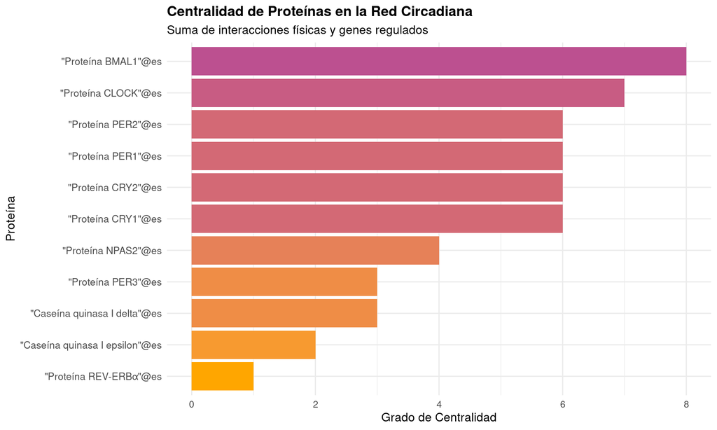

```r
ggplot(resultados4b, aes(x = reorder(nombreProteina, gradoCentralidad),
                        y = gradoCentralidad,
                        fill = gradoCentralidad)) +
  geom_col() +
  coord_flip() +
  scale_fill_gradient(low = "#ffa600", high = "#bc5090") +
  labs(title = "Centralidad de Proteínas en la Red Circadiana",
       subtitle = "Suma de interacciones físicas y genes regulados",
       x = "Proteína",
       y = "Grado de Centralidad",
       fill = "Centralidad") +
  theme_minimal(base_size = 12) +
  theme(legend.position = "none",
        plot.title = element_text(face = "bold", size = 14),
        axis.text.y = element_text(size = 10))
```

# 9 Consulta 5 (Federada): Información de Proteínas desde UniProt

## 9.1 Pregunta de Investigación

> *¿Qué nombres recomendados reporta UniProt para las proteínas del grafo?*

## 9.2 Interés Biomédico

Enriquece el grafo local con información básica de UniProt para:

- Validar identidades proteicas con nomenclatura oficial
- Verificar la interoperabilidad con bases de datos internacionales

## 9.3 Consulta SPARQL (Federada)

```r
# Aumentar timeout solo para esta consulta (SERVICE a UniProt puede tardar)
old_timeout <- getOption("timeout")
options(timeout = 300)
on.exit(options(timeout = old_timeout), add = TRUE)

consulta5_federada <- '
PREFIX rdfs: <http://www.w3.org/2000/01/rdf-schema#>
PREFIX biolink: <https://w3id.org/biolink/vocab/>
PREFIX up: <http://purl.uniprot.org/core/>

SELECT ?nombreLocal ?uniprotId ?nombreUniprot
WHERE {
  ?proteinaLocal a biolink:Protein ;
                 rdfs:label ?nombreLocal ;
                 rdfs:seeAlso ?uniprotUri .

  FILTER(CONTAINS(STR(?uniprotUri), "uniprot"))
  BIND(REPLACE(STR(?uniprotUri), "http://purl.uniprot.org/uniprot/", "") AS ?uniprotId)

  SERVICE SILENT <https://sparql.uniprot.org/sparql> {
    ?uniprotUri a up:Protein .
    OPTIONAL { ?uniprotUri up:recommendedName/up:fullName ?nombreUniprot . }
  }
}
ORDER BY ?nombreLocal
'

resultados5_federada <- tryCatch(
  ejecutar_consulta(consulta5_federada),
  error = function(e) {
    message(paste("Error en consulta federada a UniProt:", e$message))
    data.frame()
  }
)
```

## 9.4 Resultados

```r
if (nrow(resultados5_federada) > 0) {
  datatable(resultados5_federada, options = list(pageLength = 10),
            caption = "Información enriquecida desde UniProt")
} else {
  cat("No se pudieron obtener resultados de UniProt en esta ejecución.\n")
  cat("Suele ser por timeout/red o por restricciones del endpoint al hacer SERVICE.\n")
}
```

|  | nombreLocal | uniprotId | nombreUniprot |
| --- | --- | --- | --- |
| 1 | "Caseína quinasa I delta"@es | P48730 | Casein kinase I isoform delta |
| 2 | "Caseína quinasa I epsilon"@es | P49674 | Casein kinase I isoform epsilon |
| 3 | "Proteína BMAL1"@es | O00327 | Basic helix-loop-helix ARNT-like protein 1 |
| 4 | "Proteína CLOCK"@es | O15516 | Circadian locomoter output cycles protein kaput |
| 5 | "Proteína CRY1"@es | Q16526 | Cryptochrome-1 |
| 6 | "Proteína CRY2"@es | Q49AN0 | Cryptochrome-2 |
| 7 | "Proteína NPAS2"@es | Q99743 | Neuronal PAS domain-containing protein 2 |
| 8 | "Proteína PER1"@es | O15534 | Period circadian protein homolog 1 |
| 9 | "Proteína PER2"@es | O15055 | Period circadian protein homolog 2 |
| 10 | "Proteína PER3"@es | P56645 | Period circadian protein homolog 3 |

[output cut: 1 more lines]

# 10 Conclusiones

Este conjunto de consultas SPARQL demuestra la capacidad de extraer conocimiento estructurado de un grafo RDF biomédico que integra vocabularios estándar (BioLink, Gene Ontology, HPO, MONDO). Las consultas permiten identificar relaciones entre genes, proteínas, variantes patogénicas, fenotipos clínicos y opciones terapéuticas, facilitando la investigación traslacional en trastornos del ritmo circadiano.